# NonParametricContrasts

Guillem

18 February 2020

## Contrastes no parámetricos de forma visual

#### Histogramas

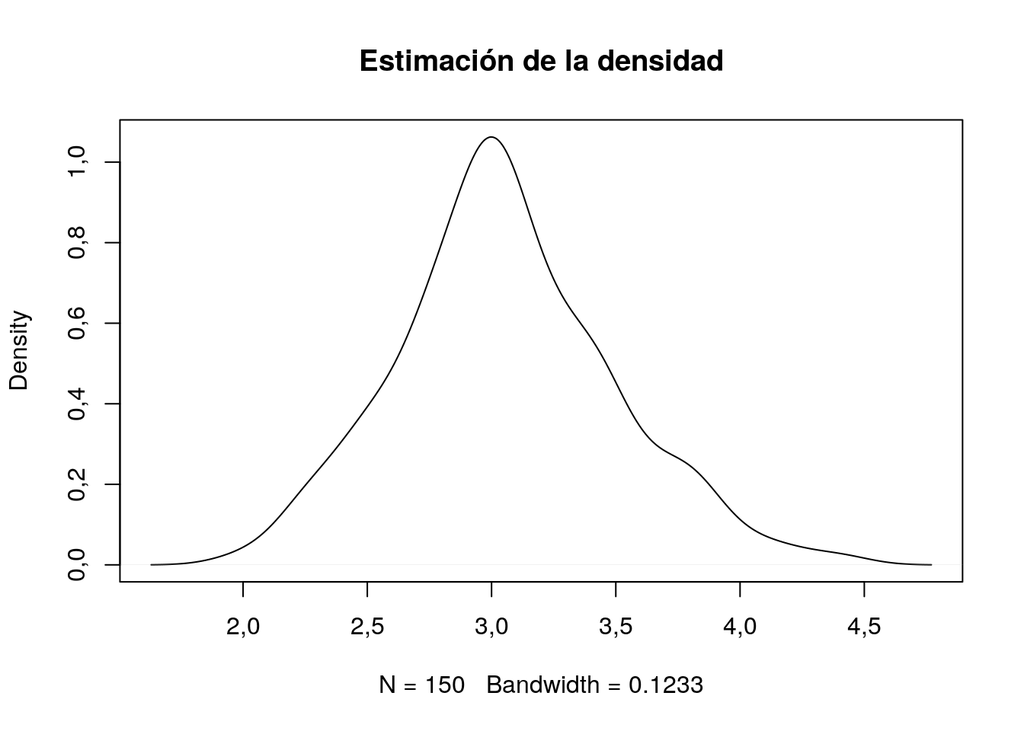

```r
muestra = iris$Sepal.Width
plot(density(muestra), main = "Estimación de la densidad")
```

Como podemos observar en el gráfico de densidad, la distribución presenta bastantes indicios de ser una normal.

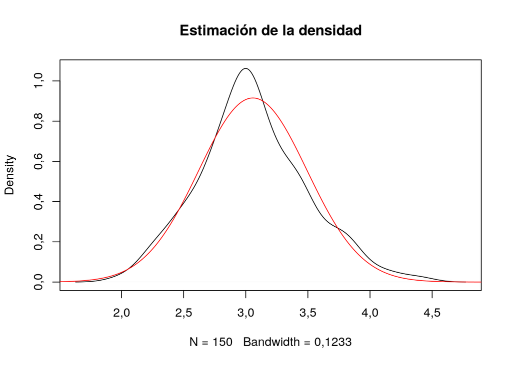

```r
muestra = iris$Sepal.Width
plot(density(muestra), main = "Estimación de la densidad")
x = seq(from=1, to = 5, by =  0.01)
mu = mean(iris$Sepal.Width)
sigma = sd(iris$Sepal.Width)
lines(x, dnorm(x,mean=mu,sd=sigma), col = "red")
```

Vemos que la campana de Gauss se parece bastante a la estimación de la densidad. La cuestión ahora es: ¿podemos aceptar que el parecido es suficiente para aceptar que la distribución de la anchura del sépalo es normal?

#### QQ-plot

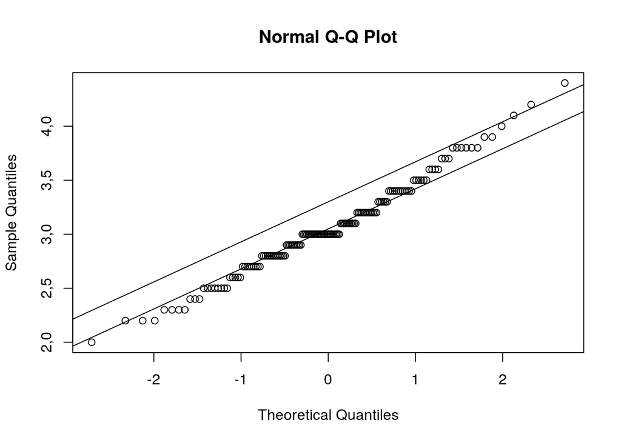

```r
qqnorm(y = iris$Sepal.Width)
qqline(y = iris$Sepal.Width, distribution = qnorm)
qqline(y = iris$Sepal.Width + 0.50/2, distribution = qnorm)
```

# Contraste $\chi²$ de Pearson

```r
set.seed(2020)
muestra_flores <- sample(iris$Species, 10)
flores_escogidas <- iris[muestra_flores,]
table(muestra_flores)
```

```
## muestra_flores
##     setosa versicolor  virginica
##          4          4          2
```

```r
chisq.test(table(muestra_flores))
```

```
##
##  Chi-squared test for given probabilities
##
## data:  table(muestra_flores)
## X-squared = 0,8, df = 2, p-value = 0,6703
```

```r
chisq.test(table(muestra_flores), simulate.p.value = TRUE, B = 2000)
```

```
##
##  Chi-squared test for given probabilities with simulated p-value (based
##  on 2000 replicates)
##
## data:  table(muestra_flores)
## X-squared = 0,8, df = NA, p-value = 0,7631
```

Con 2000 replicaciones, al obtener un p-valor grande, no tenemos suficientes evidencias para rechazar que la proporción de especies en la muestra no sea la misma

```r
extremos_izquierdos <- c(-Inf, 1.95, 2.45, 2.95, 3.45, 3.95, 4.45)
extremos_derechos <- c(1.95, 2.45, 2.95, 3.45, 3.95, 4.45, Inf)
frecuencias_empiricas <- c(2, 1,4, 15, 10, 5, 3)
n = sum(frecuencias_empiricas)
```

```r
mu = 3.5; sigma = 0.7;
probabilidades_teoricas <- pnorm(extremos_derechos, mu, sigma) - pnorm(extremos_izquierdos, mu, sigma)

chisq.test(frecuencias_empiricas, p = probabilidades_teoricas)
```

```
##
##  Chi-squared test for given probabilities
##
## data:  frecuencias_empiricas
## X-squared = 8,1337, df = 6, p-value = 0,2285
```

```r
chisq.test(frecuencias_empiricas, p = probabilidades_teoricas, simulate.p.value = TRUE, B = 2000)
```

```
##
##  Chi-squared test for given probabilities with simulated p-value (based
##  on 2000 replicates)
##
## data:  frecuencias_empiricas
## X-squared = 8,1337, df = NA, p-value = 0,2114
```

# Contraste $\chi^2$ de Pearson con parámetros desconocidos

```r
frecuencias_empiricas <- c(229, 211, 93, 35, 8)
estimacion_lambda <- (211+93*2+35*3+7*4+1*5)/(229+211+93+35+7+1)
probabilidades_esperadas <- c(dpois(0, estimacion_lambda), dpois(1, estimacion_lambda), dpois(2, estimacion_lambda), dpois(3, estimacion_lambda), 1-ppois(3, estimacion_lambda))

chisq.test(frecuencias_empiricas, p=probabilidades_esperadas)
```

```
##
##  Chi-squared test for given probabilities
##
## data:  frecuencias_empiricas
## X-squared = 1,0221, df = 4, p-value = 0,9064
```

Aunque este contraste podría ser fiable, no está teniendo en cuenta que estamos estimando un parámetro, por lo que se debería restar 1 a los grados de libertad. Como solución podemos hacer:

```r
test.chi2 = chisq.test(frecuencias_empiricas, p = probabilidades_esperadas)

pchisq(test.chi2[[1]],3, lower.tail = FALSE)
```

```
## X-squared
##  0,795905
```